# Good Plot & Bad Plot

Jonathan Huang

2023-03-28

# INTRODUCTION:

Data visualization is commonly used by scientist to communicate results of experiment. To make a good plot, its should consider the following

- Data should be free of mistakes, correctly labeled with units, and scientifically sound observation and experimental design
- Graph should be clear, simple, and easy to understand. It should not clutter, emphesize specific data, clearly labeled distinct groups, logical color schemes
- Graph should responsibly represent the data and conclusion of the study. Should not have misleading axis or labels.

# Background

This assignment will use SONGS fish size and count monitoring dataset. The objective of graphs is to show the size distribution of California Sheephead at artifical reef sites compared to natural reef sites over time.

Load Libraries

```r
library(tidyverse)
library(here)
library(patchwork)
library(ggpubr)
library(png)
library(jpeg)
library(grid)
library(ggimage)
library(cowplot)
library(magick)
```

Import Data

```r
# Our main survey data
songs <- read.csv(here("good_bad_plot","data","songs_clean.csv"))

#Add in image
kelp <- png::readPNG(here("good_bad_plot","data","kelp.png"))

imagefile <- png::readPNG(here("good_bad_plot","data","sheephead.png"))
```

set data to have individual counts

```r
songs_count <- songs %>%
  group_by( year,total_length, species_code, reef_code) %>%  #group analysis
  filter(species_code %in% "SEPU") %>%
  mutate(species_code = as_factor(factor(species_code,   #reorder the factors
  levels = c( "SEPU","PACL","PANE","EMJA","CHPU","OXCA"))),
  total_length = as.numeric(total_length), #change length to numeric
  reef_code = as_factor(reef_code),
  year = as_factor(year)) %>%
  summarise(count = sum(count), #sum the count through the years
  total_area_sampled = sum(total_area_sampled)) %>%
  mutate(size_density = count/total_area_sampled) %>%
  uncount(count) %>%   #reorder so each row = 1 count
  select(year, species_code,reef_code,total_length,total_area_sampled, size_density) #reorder df order
```

## Bad Plot

plot observed size distribution on

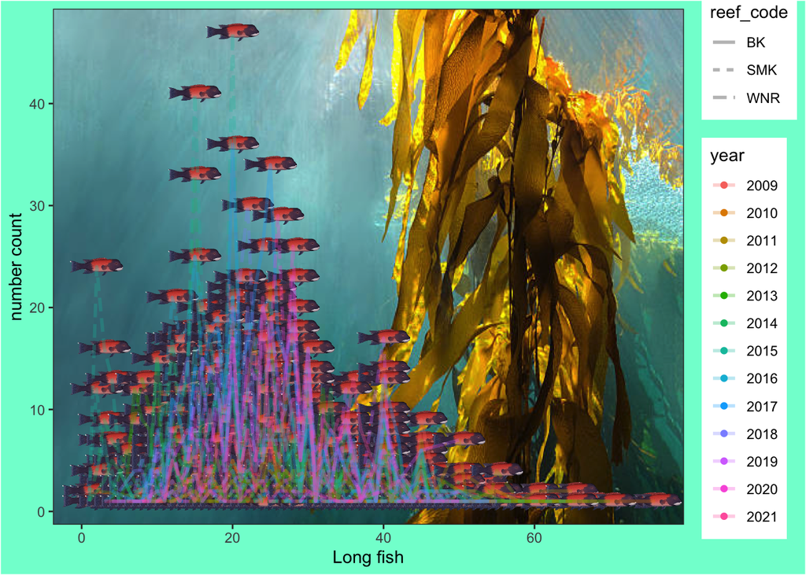

```r
 ggplot(songs_count %>%
    mutate(tally = as.character( 1)) %>% #add a column to sum count
      group_by(reef_code,total_length, year) %>% tally())+
  #Add background image with ggimage
  annotation_custom(rasterGrob(kelp,
             width = unit(1,"npc"),
  height = unit(1,"npc")),
                    -Inf, Inf, -Inf, Inf) +
  #add the geompoints
  geom_point(mapping = aes(x =total_length, y = n,color = year))+
  #replace geompoints with sheephead image
  geom_image(mapping = aes(x =total_length, y = n,image = sample(here("good_bad_plot","data","sheephead.png"))), size = 0.1, alpha = 0.2)+
  #Add a line graph to show trends in size, color by year
  geom_line(mapping = aes(x = total_length, y = n, color = year, linetype = reef_code), alpha = 0.3, size = 1)+
  #edit axis titles and limits
  xlim(c(0,max(songs_count$total_length)))+
  xlab("Long fish")+
  ylab("number count")+
  #edit background
  theme_bw()+
  theme(plot.background = element_rect(fill = "aquamarine"))
```

### This plot is bad because

- No title to describe what the graph is about
- uninformative axis titles
- uninformative legend, not specified what “reef_code” is
- line graph shows raw numbers, when comparing two sites it is not a standarized way of looking at size distribution
- Combining all the years and sites onto one graph, difficult to track changes
- Color of the lines blend into the background, difficult to see. Palatte may not be colorblind friendly
- Points are changed to fish images, which is distracting and uninformative on where the point is
- Aesthetic background to distract from from data - making it difficult to focus on the data

## Good Plot

#### Plot observed size distribution on artificial reef

```r
p1 <- ggplot(songs_count %>% filter(reef_code%in% "WNR"),    #data
       aes(x = total_length, fill = year))+   #specify x & solor by year
  geom_density(binwidth = 3)+  #use density plot
    facet_wrap(~year, ncol = 1, scales = "free_y")+    #separate plots by species
  scale_x_continuous(breaks = seq(0,75, 5),
                     limits = c(0,75))+  #scale x to be max lenght at increment of 5cm
    scale_y_continuous(breaks = seq(0,0.08, 0.05),
                      limits = c(0,0.07) )+ #scale y tick mark
  labs(x = "Total Length (mm)",    #edit axis & legend labels
       y = "Density",
       fill = "Year",
       title = element_text("Artificial Reef"))+
  scale_fill_viridis_d(option = "mako")+  #color palatte
  theme_classic()+
  theme(panel.background = element_rect(fill = "grey96", color = "black"),
        plot.title = element_text(hjust = 0.5),
        legend.position = "none",
        panel.spacing = unit(1, "mm"),
        strip.text = element_blank())
```

#### Plot observed size distribution on natural reefs

```r
p2 <- ggplot(songs_count %>% filter(reef_code%in% c("BK","SMK")),    #data
       aes(x = total_length, fill = year))+   #specify x & solor by year
  geom_density(binwidth = 3)+   #use frequency polygon
  facet_wrap(~year, ncol = 1, scales = "free_y")+    #separate plots by species
  scale_x_continuous(breaks = seq(0,max(songs$total_length), 5),
                     limits = c(0,NA))+  #scale x to be max length
    scale_y_continuous(breaks = seq(0,0.08, 0.05),
                      limits = c(0,0.07) )+ #scale y tick mark
  labs(x = "Total Length (mm)",    #edit axis & legend labels
       y = "Density",
       fill = "Year",
       title = element_text("Natrual Reef"))+
  scale_fill_viridis_d(option = "mako")+  #color palatte
  theme_classic()+
  theme(panel.background = element_rect(fill = "grey96", color = "black"),
        plot.title = element_text(hjust = 0.5),
        panel.spacing = unit(1, "mm"),
        strip.text = element_blank())
```

#### Combine the two graphs into one

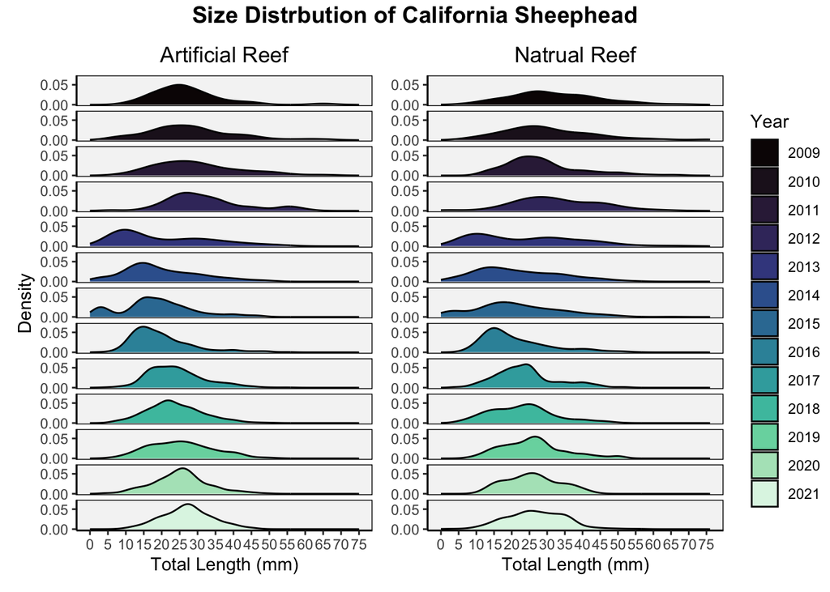

```r
#combine both plots
combined <- ggarrange(p1+p2+rremove("ylab"), common.legend = TRUE, legend = "right")
#add title at the top of the graph
annotate_figure(combined, top = text_grob("Size Distrbution of California Sheephead", face = "bold", size = 14))
```